# Introduction to mashr

Matthew Stephens

May 26, 2017

## Goal

This vignette introduces the `mashr` software for someone who is familiar with the basic idea in Urbut et al. In this first vignette we use only the “canonical” covariance matries to simplify presentation. However, an important aspect of `mashr` is the use of data-driven covariance matrices that are learned from the data, so when you are done here you should look at the data-driven vignette and the non-canonical matrix vignette.

## Outline

There are essentially four steps to a mash analysis

- Read in the data
- Set up the covariance matrices to be used
- Fit the model
- Extract posterior summaries and other quantities of interest

Here we do each of these step-by-step. However, first we simulate some data for illustration.

```r
library(ashr)
library(mashr)
set.seed(1)
simdata = simple_sims(500,5,1)
```

This simulation routine creates a dataset with 5 conditions, and four different types of effect: null, independent among conditions, condition-specific in condition 1, and shared (equal effects in all conditions). It creates 500 effects of each type for a total of 2000 effects.

## Step 1: Read in the data

To run `mash` you need data consisting of a matrix of effects (`Bhat`) and a matrix of standard errors (`Shat`), for $J$ effects (rows) in $R$ conditions (columns).

[If you have only access to $Z$ scores, you can set `Bhat` to the Z scores, and set `Shat` to be the matrix with all 1s].

The simulation above created both these matrices for us (in `simdata$Bhat` and `simdata$Shat`). To get these ready for applying `mash` you must first use `set_mash_data` to create a data object witho those two pieces of information:

```r
data = set_mash_data(simdata$Bhat, simdata$Shat)
```

# Step 2: Set up the covariance matrices

There are two types of covariance matrix you can use in `mash`: “canonical” and “data-driven”. The canonical ones are very easy to set up and so we use those here for illustration. However, in applications you will likely also want to use data-driven matrices, and this is an important feature of `mash`. See the data-driven vignette for more details on how to do this.

The function to set up canonical covariance matries is `cov_canonical`. The following sets up canonical covariances in `U.c` (we used `.c` to indicate canonical), which is a named list of matrices.

```r
U.c = cov_canonical(data)
print(names(U.c))
```

```
#  [1] "identity"      "singletons_1"  "singletons_2"  "singletons_3"
#  [5] "singletons_4"  "singletons_5"  "equal_effects" "simple_het_1"
#  [9] "simple_het_2"  "simple_het_3"
```

# Step 3: fit the model

Having set up the data and covariance matrices you are ready to fit the model using the `mash` function:

```r
m.c = mash(data, U.c)
```

```
#  - Computing 2000 x 151 likelihood matrix.
#  - Likelihood calculations took 0.04 seconds.
#  - Fitting model with 151 mixture components.
#  - Model fitting took 0.33 seconds.
#  - Computing posterior matrices.
#  - Computation allocated took 0.02 seconds.
```

This can take a little time. What this does is to fit a mixture model to the data, estimating the mixture proportions. Specifically the model is that the true effects follow a mixture of multivariate normal distributions: $B \sim \sum_k \sum_l \pi_{kl} N(0, \omega_l U_k)$ where the $\omega_l$ are scaling factors set by the “grid” parameter in `mash` and the $U_k$ are the covariance matrices (here specified by `U.c`).

## Step 4: Extract Posterior Summaries

You can extract estimates (posterior means and posterior standard deviations) and measures of significance (local false sign rates) using functions like `get_pm` (posterior mean), `get_psd` (posteriore standard deviation) and `get_lfsr` (local false sign rate):

```r
head(get_lfsr(m.c))
```

```
#        [,1]   [,2]   [,3]   [,4]   [,5]
# [1,] 0.7561 0.7706 0.8053 0.8111 0.8189
# [2,] 0.7245 0.6906 0.7760 0.6923 0.7013
# [3,] 0.7387 0.7514 0.8105 0.8390 0.8502
# [4,] 0.7856 0.8454 0.8360 0.8660 0.8503
# [5,] 0.8045 0.8371 0.8808 0.8786 0.8758
# [6,] 0.7207 0.6834 0.7894 0.7003 0.7569
```

```r
head(get_pm(m.c))
```

```
#          [,1]     [,2]       [,3]      [,4]      [,5]
# [1,]  0.07388 -0.12490 -0.0763245  0.092632 -0.045368
# [2,] -0.02354 -0.17605 -0.0324369 -0.201653 -0.170553
# [3,] -0.10218  0.18092 -0.0846330  0.022524 -0.002685
# [4,] -0.06239  0.02794  0.0654480  0.008114  0.032180
# [5,]  0.03341 -0.06060  0.0001469 -0.003888 -0.004666
# [6,] -0.09935  0.21557 -0.0791494  0.213027  0.079063
```

```r
head(get_psd(m.c))
```

```
#        [,1]   [,2]   [,3]   [,4]   [,5]
# [1,] 0.4593 0.4210 0.3545 0.4062 0.3366
# [2,] 0.4862 0.4278 0.4047 0.4448 0.4150
# [3,] 0.4679 0.5082 0.3799 0.3269 0.3284
# [4,] 0.4389 0.2964 0.3082 0.2749 0.2810
# [5,] 0.4033 0.3287 0.2608 0.2598 0.2656
# [6,] 0.5227 0.4982 0.4483 0.4907 0.3899
```

Each of these are $J \times R$ matrices.

Use `get_significant_results` to find the indices of effects that are “significant”, which here means they have lfsr less than t in at least one condition, where t is a threshold you specify (default 0.05). The output is ordered from most significant to least significant.

```r
head(get_significant_results(m.c))
```

```
# [1] 1800 1812 1857 1953 1915 1950
```

```r
print(length(get_significant_results(m.c)))
```

```
# [1] 150
```

You can also get the significant results in just a subset of conditions. For example

```r
print(head(get_significant_results(m.c, conditions=1)))
```

```
# [1] 1812 1726 1800 1501 1953 1993
```

### Sharing

Use `get_pairwise_sharing` to assess sharing of significant signals among each pair of conditions. Here the default definition of shared is “the same sign and within a factor 0.5 of each other”.

```r
print(get_pairwise_sharing(m.c))
```

```
#        [,1]   [,2]   [,3]   [,4]   [,5]
# [1,] 1.0000 0.7761 0.8015 0.7727 0.7778
# [2,] 0.7761 1.0000 0.9143 0.8972 0.8611
# [3,] 0.8015 0.9143 1.0000 0.9109 0.8962
# [4,] 0.7727 0.8972 0.9109 1.0000 0.8679
# [5,] 0.7778 0.8611 0.8962 0.8679 1.0000
```

You can change the factor if you like. For example, here by setting the factor to be 0 you assess only if they are the same sign:

```r
print(get_pairwise_sharing(m.c, factor=0))
```

```
#        [,1]   [,2]   [,3]   [,4]   [,5]
# [1,] 1.0000 0.8881 0.9237 0.8864 0.9111
# [2,] 0.8881 1.0000 0.9333 0.9252 0.9444
# [3,] 0.9237 0.9333 1.0000 0.9208 0.9717
# [4,] 0.8864 0.9252 0.9208 1.0000 0.9340
# [5,] 0.9111 0.9444 0.9717 0.9340 1.0000
```

### Measure of fit (log-likelihood)

Use `get_loglik` to find the log-likelihood of the fit (this will only be useful when you have other fits to compare it with!)

```r
print(get_loglik(m.c))
```

```
# [1] -16120
```

### Estimated mixture proportions

Use `get_estimated_pi` to extract the estimates of the mixture proportions for different types of covariance matrix:

```r
print(get_estimated_pi(m.c))
```

```
#          null      identity  singletons_1  singletons_2  singletons_3
#     3.712e-01     2.209e-01     1.365e-01     2.098e-02     1.303e-08
#  singletons_4  singletons_5 equal_effects  simple_het_1  simple_het_2
#     6.212e-10     4.962e-03     2.264e-01     1.001e-04     2.719e-09
#  simple_het_3
#     1.894e-02
```

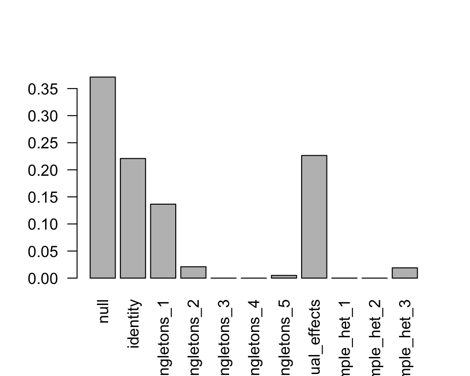

```r
barplot(get_estimated_pi(m.c),las = 2)
```

Here we can see most of the mass is on the null, identity, `singletons_1` (which corresponds to effects that are specific to condition 1) and `equal_effects`. This reassuringly matches the way that these data were generated.

### Metaplot

The following produces a meta-plot based on the posterior means and posterior variances of an effect. Here we look at the most significant result.

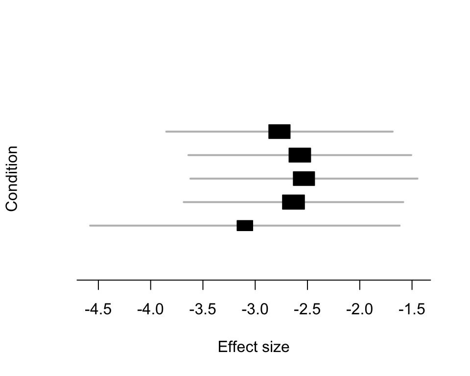

[output not shown]

```r
mash_plot_meta(m.c,get_significant_results(m.c)[1])
```